```python
import pandas as pd
import numpy as np
import matplotlib as mpl
import matplotlib.pyplot as plt
import seaborn as sns
import statsmodels.api as sm
from statsmodels.formula.api import ols
from sklearn.feature_selection import f_regression
from ggplot import *
from sklearn import linear_model
```

```python
file = "08_gap-every-five-years.tsv"

data = pd.read_csv(file, sep='\t')
data.head(5)
```

|  | country | continent | year | lifeExp | pop | gdpPercap |
| --- | --- | --- | --- | --- | --- | --- |
| 0 | Afghanistan | Asia | 1952 | 28.801 | 8425333 | 779.445314 |
| 1 | Afghanistan | Asia | 1957 | 30.332 | 9240934 | 820.853030 |
| 2 | Afghanistan | Asia | 1962 | 31.997 | 10267083 | 853.100710 |
| 3 | Afghanistan | Asia | 1967 | 34.020 | 11537966 | 836.197138 |
| 4 | Afghanistan | Asia | 1972 | 36.088 | 13079460 | 739.981106 |

# Exercise 1

**make a scatter plot of life expectancy across time**

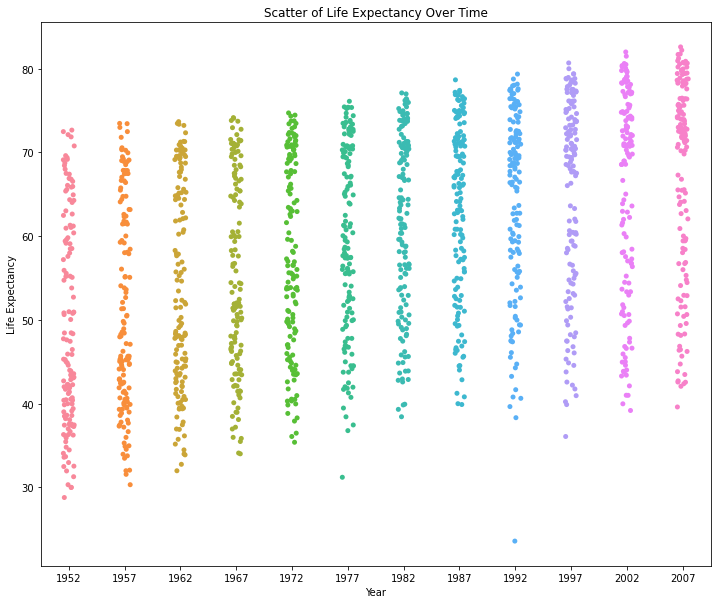

```python
plt.figure(figsize = (12, 10))
sns.stripplot(x = "year", y = "lifeExp", data = data)


plt.title("Scatter of Life Expectancy Over Time")
plt.xlabel("Year")
plt.ylabel("Life Expectancy")
```

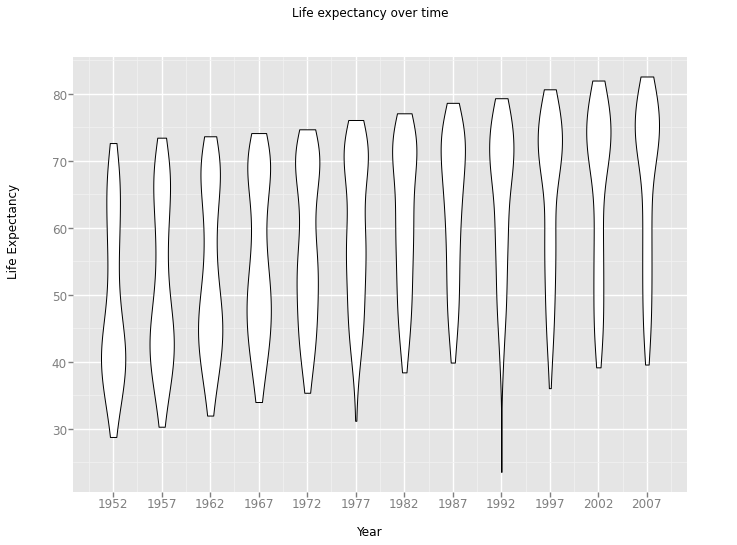

```python
#creating violin graphs
plt.figure(figsize = (12, 10))


ggplot(aes(x = 'year', y = 'lifeExp'), data = data) + geom_violin() +\
labs(title="Life expectancy over time",
         x = "Year",
         y = "Life Expectancy")
```

# Question 1

**Question 1: Is there a general trend (e.g., increasing or decreasing) for life expectancy across time? Is this trend linear? (answering this qualitatively from the plot, you will do a statistical analysis of this question shortly)**

From the data we have seen so far, there does seem to be a trend for life expectancy across time. It is linear because in the earlier years the life expectancy is noticeably lower compared to more recent years. During more recent years the concentration of the data becomes much higher in age.

**Question 2: How would you describe the distribution of life expectancy across countries for individual years? Is it skewed, or not? Unimodal or not? Symmetric around it’s center?**

The distribution is noticeably skewed. There's a tail in two specific years like 1992 and 1977. This also means it's not symmetric around it's center due to the adnormal distribution. It is not unimodal because there's multiple modes in some of the years.

**Question 3: Suppose I fit a linear regression model of life expectancy vs. year (treating it as a continuous variable), and test for a relationship between year and life expectancy, will you reject the null hypothesis of no relationship? (do this without fitting the model yet. I am testing your intuition.)**

Yes due to the existing positive relationship between years/life expectancy which means we would reject the null hypothesis of no relationship.

**Question 4: What would a violin plot of residuals from the linear model in Question 3 vs. year look like? (Again, don’t do the analysis yet, answer this intuitively)**

The violin plot of residuals will probably look linear as well.

**Question 5: According to the assumptions of the linear regression model, what should that violin plot look like? That is, consider the assumptions the linear regression model you used assumes (e.g., about noise, about input distributions, etc); do you think everything is okay?**

The plot should look as a normal distribution. Having a center around 0 and being symmetrical.

# Exercise 2

Fit a linear regression model using, e.g., the LinearRegression function from Scikit-Learn or the closed-form solution we derived in class, for life expectancy vs. year (as a continuous variable). There is no need to plot anything here, but please print the fitted model out in a readable format.

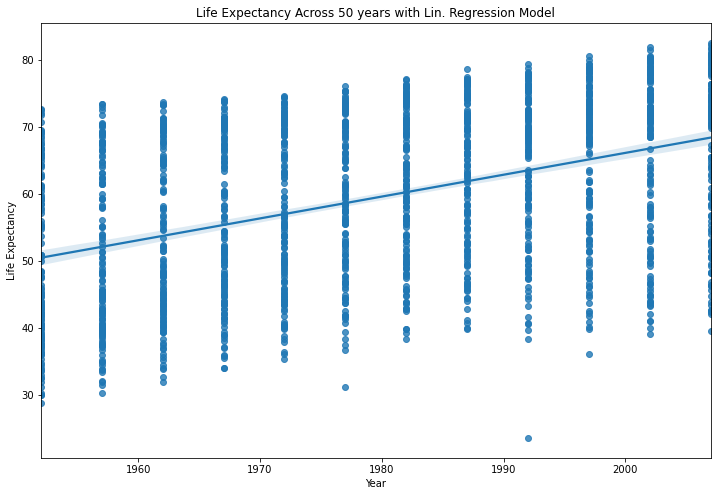

```python
plt.figure(figsize = (12, 8))

sns.regplot(x = "year", y = "lifeExp", data = data)


plt.title("Life Expectancy Across 50 years with Lin. Regression Model")
plt.xlabel("Year")
plt.ylabel("Life Expectancy")
```

# Question 6: On average, by how much does life expectancy increase every year around the world?

Life expectancy increases by .3259 years every year

```python
result1 = ols(formula = "lifeExp ~ year", data = data).fit()

#find out the information of the graph

print (result1.summary())
```

```
                            OLS Regression Results
==============================================================================
Dep. Variable:                lifeExp   R-squared:                       0.190
Model:                            OLS   Adj. R-squared:                  0.189
Method:                 Least Squares   F-statistic:                     398.6
Date:                Fri, 04 Dec 2020   Prob (F-statistic):           7.55e-80
Time:                        02:06:08   Log-Likelihood:                -6597.9
No. Observations:                1704   AIC:                         1.320e+04
Df Residuals:                    1702   BIC:                         1.321e+04
Df Model:                           1
Covariance Type:            nonrobust
==============================================================================
                 coef    std err          t      P>|t|      [0.025      0.975]
------------------------------------------------------------------------------
Intercept   -585.6522     32.314    -18.124      0.000    -649.031    -522.273
year           0.3259      0.016     19.965      0.000       0.294       0.358
==============================================================================
Omnibus:                      386.124   Durbin-Watson:                   0.197
Prob(Omnibus):                  0.000   Jarque-Bera (JB):               90.750
Skew:                          -0.268   Prob(JB):                     1.97e-20
Kurtosis:                       2.004   Cond. No.                     2.27e+05
==============================================================================

Warnings:
[1] Standard Errors assume that the covariance matrix of the errors is correctly specified.
[2] The condition number is large, 2.27e+05. This might indicate that there are
strong multicollinearity or other numerical problems.
```

# Question 7: Do you reject the null hypothesis of no relationship between year and life expectancy? Why?

Yes, I reject the null hypothesis because the p value is 0, which means the probability of the null hypothesis of being true is also 0

# Exercise 3:

**Make a violin plot of residuals vs. year for the linear model from Exercise 2.**

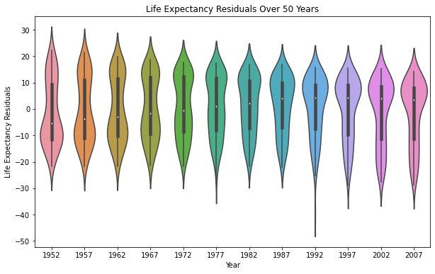

```python
slope = result1.params.year
a = result1.params.Intercept

data['expected'] = 0.0

for i, row in data.iterrows():

    e = slope * (row['year']) + a
    data.at[i, 'expected'] = e


data['residuals'] = data['lifeExp'] - data['expected']



plt.figure(figsize = (10, 6))

sns.violinplot(x = 'year', y = 'residuals', data = data)

plt.title("Life Expectancy Residuals Over 50 Years")

plt.xlabel("Year")

plt.ylabel("Life Expectancy Residuals")
```

**Question 8: Does the plot of Exercise 3 match your expectations (as you answered Question 4)?**

# Exercise 4

Make a boxplot (or violin plot) of model residuals vs. continent.

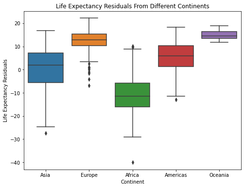

```python
plt.figure(figsize = (8, 6))

sns.boxplot(x = 'continent', y = 'residuals', data = data)

plt.title("Life Expectancy Residuals From Different Continents")

plt.xlabel("Continent")
plt.ylabel("Life Expectancy Residuals")
```

**Question 9: Is there a dependence between model residual and continent? If so, what would that suggest when performing a regression analysis of life expectancy across time?**

Yes there's a dependence between the continent and model residual. Each box is unqiuely shapped. This provides evidence that the continents affect the life expectancy across time by varying amounts.

# Exercise 5

Make a scatter plot of life expectancy vs. year, grouped by continent, and add a regression line.

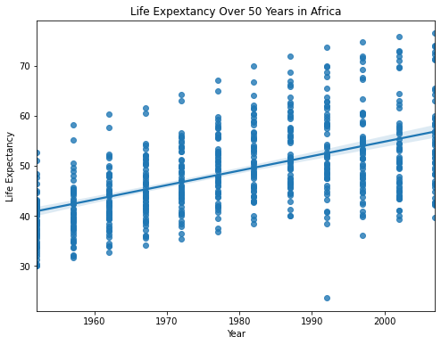

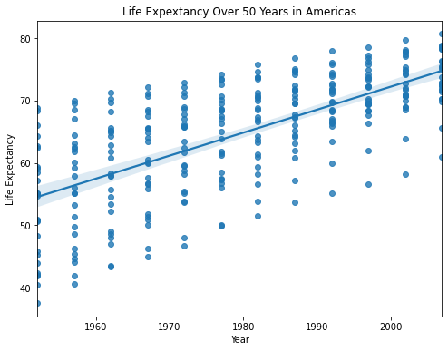

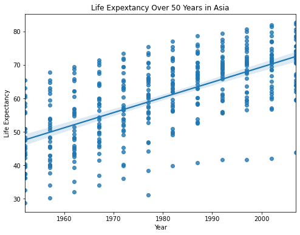

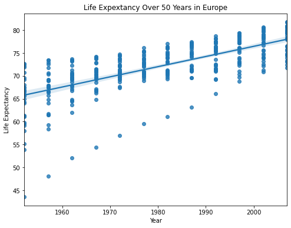

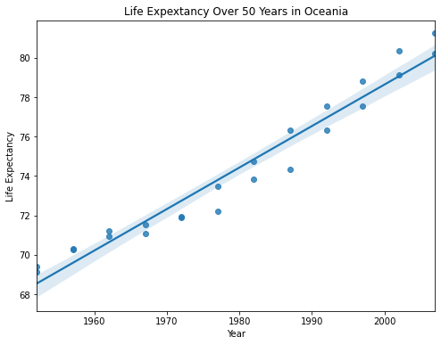

```python
continent = np.unique(data['continent'])

for c in continent:

    p = data.drop(data[c != data['continent']].index)
    plt.figure(figsize = (8, 6))

    sns.regplot(x = "year", y = "lifeExp", data = p)
    plt.title("Life Expextancy Over 50 Years in " + c)
    plt.xlabel("Year")

    plt.ylabel("Life Expectancy")
```

**Question 10: Based on this plot, should your regression model include an interaction term for continent and year? Why?**

Yes, due to the significant differences across the continents life expectancy rates the model should consider the continent and year. Both play a heavy role in effecting the life expectancy.

# Exercise 6:

Fit a linear regression model for life expectancy including a term for an interaction between continent and year. Print out the model in a readable format, e.g., print the coefficients of the model (no need to plot). Hint: adding interaction terms is a form of feature engineering, like we discussed in class (think about, e.g., using (a subset of) polynomial features here).

```python
regression = ols(formula = 'lifeExp ~ year * continent', data = data).fit()

print(regression.summary())
```

```
                            OLS Regression Results
==============================================================================
Dep. Variable:                lifeExp   R-squared:                       0.693
Model:                            OLS   Adj. R-squared:                  0.691
Method:                 Least Squares   F-statistic:                     424.3
Date:                Fri, 04 Dec 2020   Prob (F-statistic):               0.00
Time:                        02:06:09   Log-Likelihood:                -5771.9
No. Observations:                1704   AIC:                         1.156e+04
Df Residuals:                    1694   BIC:                         1.162e+04
Df Model:                           9
Covariance Type:            nonrobust
==============================================================================================
                                 coef    std err          t      P>|t|      [0.025      0.975]
----------------------------------------------------------------------------------------------
Intercept                   -524.2578     32.963    -15.904      0.000    -588.911    -459.605
continent[T.Americas]       -138.8484     57.851     -2.400      0.016    -252.315     -25.382
continent[T.Asia]           -312.6330     52.904     -5.909      0.000    -416.396    -208.870
continent[T.Europe]          156.8469     54.498      2.878      0.004      49.957     263.737
continent[T.Oceania]         182.3499    171.283      1.065      0.287    -153.599     518.298
year                           0.2895      0.017     17.387      0.000       0.257       0.322
year:continent[T.Americas]     0.0781      0.029      2.673      0.008       0.021       0.135
year:continent[T.Asia]         0.1636      0.027      6.121      0.000       0.111       0.216
year:continent[T.Europe]      -0.0676      0.028     -2.455      0.014      -0.122      -0.014
year:continent[T.Oceania]     -0.0793      0.087     -0.916      0.360      -0.249       0.090
==============================================================================
Omnibus:                       27.121   Durbin-Watson:                   0.242
Prob(Omnibus):                  0.000   Jarque-Bera (JB):               44.106
Skew:                          -0.121   Prob(JB):                     2.65e-10
Kurtosis:                       3.750   Cond. No.                     2.09e+06
==============================================================================

Warnings:
[1] Standard Errors assume that the covariance matrix of the errors is correctly specified.
[2] The condition number is large, 2.09e+06. This might indicate that there are
strong multicollinearity or other numerical problems.
```

# Question 11:

**Are all parameters in the model significantly different from zero? If not, which are not significantly different from zero?**

# Question 12:

**On average, by how much does life expectancy increase each year for each continent? (Provide code to answer this question by extracting relevant estimates from model fit)**

```python
regression.params
```

```
Intercept                    -524.257846
continent[T.Americas]        -138.848447
continent[T.Asia]            -312.633049
continent[T.Europe]           156.846852
continent[T.Oceania]          182.349883
year                            0.289529
year:continent[T.Americas]      0.078122
year:continent[T.Asia]          0.163593
year:continent[T.Europe]       -0.067597
year:continent[T.Oceania]      -0.079257
dtype: float64
```

# Exercise 8:

**Make a residuals vs. year violin plot for the interaction model. Comment on how well it matches assumptions of the linear regression model.**

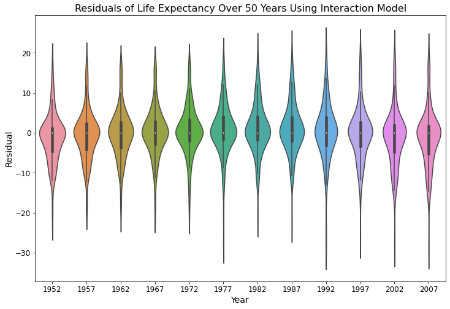

```python
pd.set_option('mode.chained_assignment', None)

e8 = data[['continent', 'year', 'lifeExp']];
e8 = e8.sort_values(by='continent').reset_index(drop=True)


mAF = regression.params[5]
bAF = regression.params[0]
mAM = mAF + regression.params[6]
bAM = bAF + regression.params[1]
mAS = mAF + regression.params[7]
bAS = bAF + regression.params[2]
mEU = mAF + regression.params[8]
bEU = bAF + regression.params[3]
mOC = mAF + regression.params[9]
bOC = bAF + regression.params[4]

e8['res'] = 0

e8['res'][e8['continent'] == 'Africa']  = e8['lifeExp'] - ((mAF*e8['year'])+bAF)

e8['res'][e8['continent'] == 'America'] = e8['lifeExp'] - ((mAM*e8['year'])+bAM)

e8['res'][e8['continent'] == 'Asia']    = e8['lifeExp'] - ((mAS*e8['year'])+bAS)

e8['res'][e8['continent'] == 'Europe']  = e8['lifeExp'] - ((mEU*e8['year'])+bEU)

e8['res'][e8['continent'] == 'Oceania'] = e8['lifeExp'] - ((mOC*e8['year'])+bOC)



plt.figure(figsize=(12,8))
sns.violinplot(x='year', y='res', data=e8);
plt.xlabel('Year', fontsize=14)
plt.xticks(fontsize=12)
plt.ylabel('Residual', fontsize=14)
plt.yticks(fontsize=12)
plt.title('Residuals of Life Expectancy Over 50 Years Using Interaction Model', fontsize=16)
```

# Part 2: Classification

```python
import sklearn.datasets
from numpy import array
import sklearn.linear_model as lm
```

```python
def grad_descent_linreg(X, y, T, alpha):
    m, n = X.shape       # m = #examples, n = #features
    theta = np.zeros(n)  # initialize parameters
    cost = np.zeros(T)   # track loss over time

    for i in range(T):
        # calculate cost for current parameter vector theta
        cost[i] = 0.5*np.linalg.norm(X.dot(theta) - y)**2
        # compute steepest ascent at f(theta)
        grad = X.T.dot(X.dot(theta) - y)
        # step down the gradient
        theta = theta - alpha*grad
    return theta, cost
```

# Problem 2 (This problem is +5 points of extra credit.) Derive the above update equation. Write the derivation in a markdown ipynb cell

The gradient descent update equation for logistic regression is given by:$$\beta^{k+1} = \beta^{k} + \alpha\sum_{i=1}^{n}(y_i - p_i(\beta^k))x_i$$

$$\begin{align}p_i(\beta^k) = \frac{e^{f_i(\beta^k)}}{1+e^{f_i(\beta^k)}} \textrm{ and } f_i(\beta^k) = \beta_0^k + \beta_1^k x_{i1} + \beta_2^k x_{i2} + ... + \beta_p^k x_{ip}\end{align}$$

generic cost function:$$C = \sum_{i=1}^{n} cost(p_i(\beta^k), y_i)$$

create convex cost function so gradient descent can converges to a global minimum. If we let y be our binary classification, we can define cost as:$$cost(p_i(\beta^k), y_i) = \begin{cases} -log(p_i(\beta^k) &amp; \text{if $y=1$} \\ -log(1 - p_i(\beta^k)) &amp; \text{if $y=0$} \end{cases} $$

re-write while removing i's:$$ cost(p(\beta^k), y) = -ylog(p(\beta^k)) - (1-y)log(1-p(\beta^k))$$

When y = 0, $cost = -0log(p(\beta^k)) - (1-0)log(1-p(\beta^k)) = -log(1-p(\beta^k))$.

When y = 1, $cost = -1log(p(\beta^k)) - (1-1)log(1-p(\beta^k)) = -log(p(\beta^k))$.

Making the cost function over i be:$$-\sum_{i=1}^{n} y log(p(\beta^k)) + (1-y)log(1-p(\beta^k))$$

going back to the logit function with this:$$p_i(\beta^k) = \frac{e^{f_i(\beta^k)}}{1+e^{f_i(\beta^k)}} * \frac{1+e^{-f_i(\beta^k)}}{1+e^{-f_i(\beta^k)}} = \frac{e^{f_i(\beta^k)}+e^{f_i(\beta^k)}e^{-f_i(\beta^k)}}{(1+e^{f_i(\beta^k)})(1+e^{-f_i(\beta^k)})} = \frac{e^{f_i(\beta^k)}+1}{(e^{f_i(\beta^k)}+1)(1+e^{-f_i(\beta^k)})} = \frac{1}{(1+e^{-f_i(\beta^k)})} $$

so we see that (again removing i's for readability/simplicity):$$p(\beta^k) = \frac{e^{f(\beta^k)}}{1+e^{f(\beta^k)}} = \frac{1}{1+e^{-f(\beta^k)}}$$

Let's also take the derivative of the logit, as it will be useful later.$$p(\beta^k) = \frac{1}{1+e^{-f(\beta^k)}} = (1+e^{-f(\beta^k)})^{-1} $$

$$p'(\beta^k) = -(1+e^{-f(\beta^k)})^{-2} * -e^{-f(\beta^k)} * f'(\beta^k) = \frac{e^{-f(\beta^k)}}{(1+e^{-x})^2} * f'(\beta^k) = \frac{1}{1+e^{-f(\beta^k)}} * \frac{e^{-f(\beta^k)}}{1+e^{-f(\beta^k)}} * f'(\beta^k) = \frac{1}{1+e^{-f(\beta^k)}} * (1 - \frac{1}{1+e^{-f(\beta^k)}}) * f'(\beta^k) $$$$p'(\beta^k) = p(\beta^k)(1-p(\beta^k)) * f'(\beta^k) $$

we use the gradient similar to what we did with linear regression. Then we use L to be the summation argument. $$L(\beta^k) = y log(p(\beta^k)) + (1-y)log(1-p(\beta^k))$$

$$ \frac{\partial}{\partial \beta^k}L(\beta^k) = y * \frac{1}{p(\beta^k)} * p'(\beta^k) + (1-y) * \frac{1}{1-p(\beta^k)} * -p'\beta^k $$$$ = \bigg(\frac{y}{p(\beta^k)} - \frac{1-y}{1-p(\beta^k)}\bigg)p'\beta^k $$$$ = \bigg(\frac{y}{p(\beta^k)} - \frac{1-y}{1-p(\beta^k)}\bigg)(p(\beta^k)(1-p(\beta^k)) * f'(\beta^k))$$$$ = \bigg(\frac{y(p(\beta^k))(1-p(\beta^k))}{p(\beta^k)} - \frac{(1-y)(p(\beta^k))(1-p(\beta^k))}{1-p(\beta^k)}\bigg) * \frac{\partial}{\partial \beta^k}f(\beta^k)$$$$ = \Big(y(1-p(\beta^k)) - (1-y)(p(\beta^k))\Big)x_i$$$$ = \Big(y-yp(\beta^k) - p(\beta^k) + yp(\beta^k)\Big)x_i$$$$ = (y - p(\beta^k))x_i$$

we then continously calculate all parameters by using alpha, learning rate, and the gradient. the following is the equation :$$ \theta_{n+1} = \theta{n} - \alpha \cdot \nabla $$

The result then becomes a double negative due to the negative rooting from our summation. Out final equation is:$$\beta^{k+1} = \beta^{k} + \alpha\sum_{i=1}^{n}(y_i - p_i(\beta^k))x_i$$

# Problem 3:

**Implement the gradient descent algorithm (either batch or stochastic versions) for multiple logistic regression. I.e., modify your code in problem 1 for the logistic regression update equation.**

```python
def logit(x):
    return (np.exp(x)/(1+np.exp(x)))

# We are using the batch version of logistic gradient descent.
def logistic_grad_descent(X, y, T, alpha):
    m, n = X.shape          # m = #examples, n = #features
    theta = np.zeros(n)     # initialize parameters
    cost2 = np.zeros(T)      # track loss over time

    for i in range(T):
        p = logit(X.dot(theta))
        # calculate cost for current parameter vector theta
        cost2[i] = (np.log(1+np.exp(p.dot(y))))
        # compute steepest ascent at f(theta)
        g = X.T.dot(p-y)
        # step down the gradient
        theta = theta + alpha*g
    return theta, cost2
```

# Problem 4:

**To test your programs, simulate data from the linear regression and logistic regression models and check that your implementations recover the simulation parameters properly.**

```python
# Generate data for linear regression:
gen_data_x, gen_data_y = sklearn.datasets.make_regression(n_samples=100, n_features=20, noise = 1.5)

# Generate data for logistic regression. This is similar to linear, only now values are either 0 or 1.
log_gen_data_x, dump_y = sklearn.datasets.make_regression(n_samples=100, n_features=20, noise = 1.5)
log_gen_data_y = [0 if i>0 else 1 for i in dump_y]
```

```python
# simulate data for linear regression
gen_data_x, gen_data_y, coef = \
sklearn.datasets.make_regression(n_samples=100, n_features=20, noise = 1.5, coef=True)

#simulate data for logistic regression.  This is similar to linear, only now values are either 0 or 1.
log_gen_data_x, dump_y, log_coef = \
sklearn.datasets.make_regression(n_samples=100, n_features=20, noise = 1.5, coef=True)
log_gen_data_y = [0 if i>0 else 1 for i in dump_y]
```

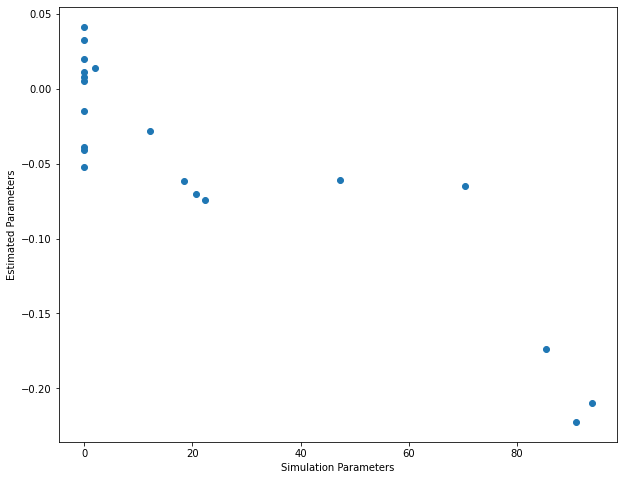

```python
theta, cost = logistic_grad_descent(gen_data_x, gen_data_y, 2000, .00000001)

plt.figure(figsize=(10,8))
plt.scatter(coef,theta)
plt.xlabel('Simulation Parameters', fontsize=10)
plt.ylabel('Estimated Parameters', fontsize=10)
```

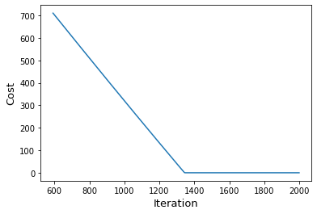

```python
plt.plot(np.arange(2000), cost)
plt.xlabel('Iteration', fontsize=13)
plt.ylabel('Cost', fontsize=13)
plt.show()
```

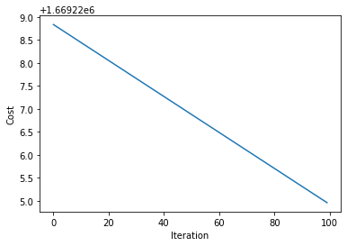

```python
theta, cost = grad_descent_linreg(gen_data_x, gen_data_y, 100, .0000000001)
plt.plot(np.arange(100), cost)
plt.xlabel('Iteration', fontsize=10)
plt.ylabel('Cost', fontsize=10)
plt.show()
```

# Try It Out

```
0.9300699300699301
0.9297619047619046
```

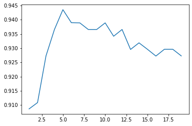

```python
from sklearn.datasets import load_breast_cancer
from sklearn.neighbors import KNeighborsClassifier     #KNN
from sklearn.ensemble import RandomForestClassifier    #Random Forest
from sklearn.model_selection import train_test_split, KFold, cross_val_score
import numpy as np

cancer = load_breast_cancer()

# constructing the k nearest neighbors
X_train, X_test, y_train, y_test = \
                                train_test_split(cancer.data, cancer.target, stratify=cancer.target, random_state=42)

kf = KFold(n_splits=10)

training_accuracy = []
test_accuracy = []

# doing K nearest with range 1 to 20
neighbors_setting = range(1,20)

# Refining parameters with cross validation
for n_neighbors in neighbors_setting:

    knn = KNeighborsClassifier(n_neighbors=n_neighbors)
    k_fold_training_accuracy = []
    for train, test in kf.split(X_train):

        knn.fit(X_train[train],y_train[train])

        k_fold_training_accuracy.append(knn.score(X_train[test], y_train[test]))

    test_accuracy.append(np.mean(k_fold_training_accuracy))

plt.plot(range(1,20), test_accuracy)

# Plot to then find what the best k value is
best_n_neighbors = KNeighborsClassifier(n_neighbors=5)
best_n_neighbors.fit(X_train,y_train)
print(best_n_neighbors.score(X_test, y_test))

scores = cross_val_score(best_n_neighbors, cancer.data, cancer.target, cv=10)
print(scores.mean())
```

```python
from sklearn.ensemble import RandomForestClassifier
# constructing the random forests
X_train, X_test, y_train, y_test = train_test_split(cancer.data, cancer.target, random_state=34)


forest_sqrt = RandomForestClassifier(n_estimators=100, random_state=0, max_features='sqrt')

#applying the cross validation to the scores
scores = cross_val_score(forest_sqrt, X_train, y_train, cv=10)
# print avg score
print(scores.mean())

forest_sqrt.fit(X_train,y_train)

# check the accuracy
print(forest_sqrt.score(X_test,y_test))
```

```
0.9506644518272426
0.972027972027972
```

```python
def logit(x):
    return (np.exp(x)/(1+np.exp(x)))

def logistic_grad_descent(X, y, T, alpha):

    m, n = X.shape
    theta = np.zeros(n)
    cost = np.zeros(T)

    for i in range(T):

        p = logit(X.dot(theta))

        cost[i] = (np.log(1+np.exp(p.dot(y))))

        g = X.T.dot(p-y)

        theta = theta + alpha*g
    return theta, cost

def score_log_reg(y_pred,y_test):

    count = 0

    length = 0
    for p ,t in zip(y_predict, y_test):

        if p ==t:
            count+=1
        length+=1

    return count/length

X_train, X_test, y_train, y_test = train_test_split(cancer.data, cancer.target, random_state=34)
T = 100000
alpha = .0000000000005
theta, f = logistic_grad_descent(X_train, y_train, T, alpha )

y_predict = list(logit(X_test.dot(theta)).round())

print(score_log_reg(list(logit(X_train.dot(theta)).round()), y_train))

# testing the entirety score accuracy
score = score_log_reg(y_predict, y_test)
print(score)
```

[output not shown]

```python
# total score will be put here
score= []

kf = KFold(n_splits=10)

for train, test in kf.split(cancer.data):

    theta, f = logistic_grad_descent(cancer.data[train], cancer.target[train], T, alpha)

    y_predict = list(logit(cancer.data[test].dot(theta)).round())

    score.append(score_log_reg(y_predict, cancer.target[test]))

# total score across everything
print(np.mean(score))
```

[output not shown]

For the try it out I used a database which is closely related to me, due to my family history of defeating breast cancer I set sights into learning more about tumors being malignant or benign. sklearns has a great breast cancer data set. Using cancer.data to then check results. This data set consists of 529 total cases with every case having 30 features each.

To begin I chose the random forests algorithm and the knearest neighbors algorithm. For the K nearest I applied the 10 fold cross validation to refine the parameters to get the k value nearest to accurate as it can be from a range of k = 1 to k = 20. Then after 10 trials I received the 93% accuracy when predicting testing data. For the random forests algorithm I used 100 decision trees which contains a high number of estimators and used sqrt for the features to be considered since it produced the highest accuracy score out of all options.